# Assignment_4_Johan_Wille

```python
import pandas as pd
import numpy as np
import matplotlib.pyplot as plt
import cvxpy as cvx
from scipy.optimize import minimize
import statsmodels.api as sm
```

```python
data = pd.read_csv("Dow_SP9624_weekly.csv", sep = ";", index_col =0, parse_dates = True)
data.index = data.index.date
data.head()
```

|  | AAPL | AXP | BA | CAT | CSCO | CVX | DIS | HD | IBM | INTC | ... | MSFT | NKE | PFE | PG | TRV | UNH | VZ | WMT | XOM | ^GSPC |
| --- | --- | --- | --- | --- | --- | --- | --- | --- | --- | --- | --- | --- | --- | --- | --- | --- | --- | --- | --- | --- | --- |
| 1996-01-12 | 0.254233 | 7.663513 | 23.880096 | 6.938046 | 2.552364 | 8.930280 | 14.786437 | 5.581314 | 10.410365 | 3.992195 | ... | 3.279934 | 3.103797 | 3.643971 | 10.139450 | 13.143141 | 5.530187 | 7.877826 | 2.311819 | 7.918760 | 601.809998 |
| 1996-01-19 | 0.224213 | 8.424948 | 24.072060 | 7.042779 | 2.737578 | 9.163610 | 14.786437 | 5.629428 | 12.293569 | 3.622060 | ... | 3.514215 | 3.167024 | 3.666192 | 10.364306 | 13.585177 | 5.761628 | 7.920798 | 2.065053 | 8.067941 | 611.830017 |
| 1996-01-26 | 0.229842 | 8.474078 | 23.572958 | 7.430732 | 2.931829 | 8.909063 | 14.971270 | 5.789812 | 12.625010 | 3.877629 | ... | 3.461620 | 3.172773 | 3.903197 | 10.379222 | 13.703052 | 6.041790 | 7.763237 | 2.078041 | 7.931192 | 621.619995 |
| 1996-02-02 | 0.219522 | 8.793386 | 23.956884 | 7.565022 | 3.053801 | 8.951490 | 15.279313 | 5.837925 | 13.212582 | 4.003953 | ... | 3.557245 | 3.121044 | 4.021699 | 9.946754 | 13.378902 | 6.187963 | 7.892154 | 2.233893 | 8.030642 | 635.840027 |
| 1996-02-09 | 0.208265 | 9.309203 | 25.456835 | 7.714235 | 3.297743 | 9.290877 | 15.464144 | 6.030385 | 13.709486 | 4.092143 | ... | 3.829778 | 3.126789 | 4.099103 | 10.468701 | 13.673583 | 6.285413 | 8.293211 | 2.324808 | 8.293435 | 656.369995 |

5 rows × 26 columns

# 1. The mean-volatility diagram

At the starting point, using the first 100 weekly returns to estimate the parameters:

a) Plot the individual stocks (assuming 100 invested in each of the stocks) in a mean-volatility diagram with x-limits: [0, 8] and y-limits: [99, 102]

**Method:**

- Import weekly price data and convert it to weekly simple returns.
- Select the first 100 weekly return observations for all individual stocks.
- Compute each stock’s mean return based on an initial investment value of 100.
- Calculate the volatility of each stock using the standard deviation of weekly returns.
- Plot each stock in a mean–volatility diagram and set the axis limits to [0,8] for volatility and [99,102] for mean return.

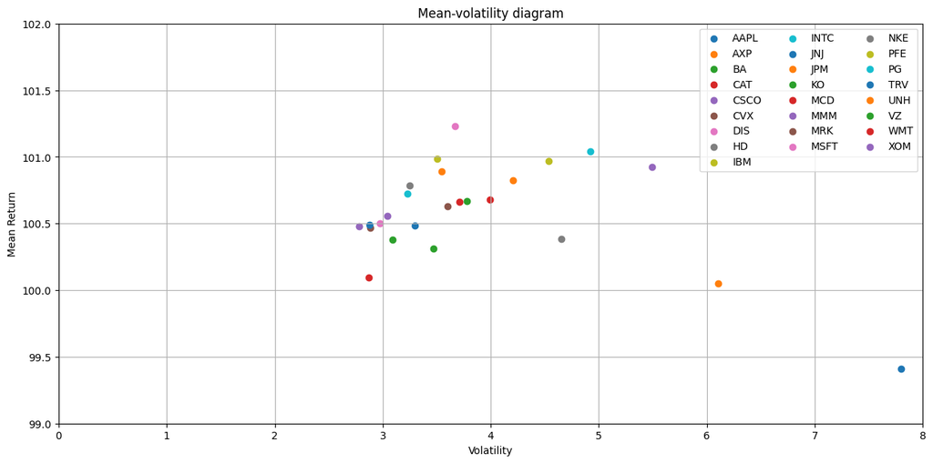

```python
gross_return = data.pct_change().dropna()
gross_return_100 = gross_return[:100].iloc[:,:-1]
mu_100 = 100 + gross_return_100.mean()*100
gross_return_vol = 100*gross_return_100.std()
covMat = gross_return_100.cov()

sp500_returns = gross_return.iloc[100:,-1].values

plt.figure(figsize = (15,7))
for i in gross_return_100.columns:
    plt.scatter(gross_return_vol[i], mu_100[i], label = i)

plt.xlabel('Volatility')
plt.ylabel('Mean Return')
plt.title('Mean-volatility diagram')
plt.legend(ncol=3)
plt.xlim(0.0, 8)
plt.ylim(99, 102)
plt.grid(True)
plt.show()
```

## b) Plot the MVS, with and without short selling allowed, in the same mean-volatility diagram.

**Method:**

- Use the estimated mean returns and covariance matrix from the first 100 weekly observations.
- Define a function that computes the minimum-variance portfolio for a chosen target return, both with and without short-selling constraints.
- For a grid of target returns, solve the optimization problem to obtain the portfolio with minimum variance.
- Store the resulting volatilities for cases with and without short selling.

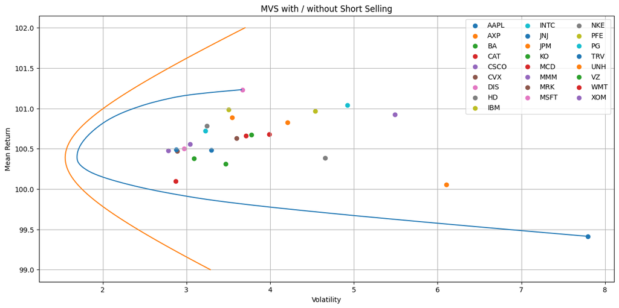

```python
def MVS(returns, Sigma_mat, target_returns, allow_short = False):
  w = cvx.Variable(25)
  objective_function = cvx.quad_form(w, Sigma_mat)
  one = np.ones(25,)
  constraints_list = [w @ one == 1, cvx.matmul(w, returns) == target_returns]
  if not allow_short:
    constraints_list.append(w >= 0)

  problem = cvx.Problem(cvx.Minimize(objective_function), constraints_list)
  problem.solve()
  vol_objective_function = cvx.sqrt(objective_function)*100
  portfolio_return = cvx.matmul(w, returns)
  return w.value, vol_objective_function.value, portfolio_return.value

target_returns = np.linspace(min(mu_100), max(mu_100), 100)
target_returns_short = np.linspace(99, 102, 100)

volatility_no_short = []
volatility_short = []
weights = []
portfolio_ret = []

for i in target_returns:
    w, vol_objective_function, portfolio_return = MVS(mu_100, covMat, i, allow_short=False)
    volatility_no_short.append(vol_objective_function)
    weights.append(w)
    portfolio_ret.append(portfolio_return)

for k in target_returns_short:
    w, vol_objective_function, portfolio_return = MVS(mu_100, covMat, k, allow_short = True)
    volatility_short.append(vol_objective_function)

plt.figure(figsize=(15, 7))
for i in gross_return_100.columns:
    plt.scatter(gross_return_vol[i], mu_100[i], label = i)

plt.legend(ncols=3)
plt.plot(volatility_no_short, target_returns, label='Without Short Selling')
plt.plot(volatility_short, target_returns_short, label='With Short Selling')
plt.title('MVS with / without Short Selling')
plt.xlabel('Volatility')
plt.ylabel('Mean Return')
plt.grid(True)
plt.show()
```

## c) Plot, in the same mean-volatility diagram, the Sharpe portfolio for the case when shorting is allowed.

**Method:**

- Convert the estimated mean returns to return rates and use the covariance matrix from the first 100 observations.
- Compute the maximum Sharpe ratio portfolio using the analytical solution under the assumption that short selling is allowed.
- Calculate the portfolio’s mean return and volatility.

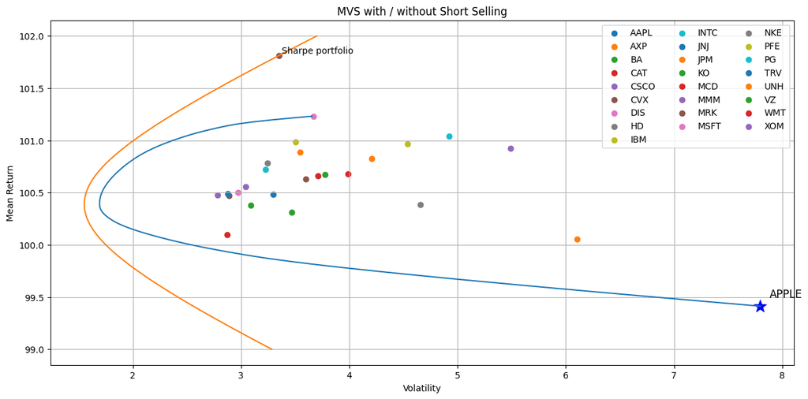

```python
muReturns =  mu_100/100
oneVector = np.ones(25)
w_MSR = ((np.linalg.inv(covMat) @ (muReturns - oneVector))/((oneVector.T @ np.linalg.inv(covMat)) @ (muReturns - oneVector))) #Lecture 23, slide 2
muSharpe = w_MSR.T @ muReturns
volSharpe = 100*np.sqrt(((w_MSR.T @ covMat) @ w_MSR))

apple_vol = gross_return_vol["AAPL"]
apple_mu = mu_100["AAPL"]
#print("Apple location → Volatility:", apple_vol, ", Mean Return:", apple_mu)

# Plotting the results
plt.figure(figsize=(15, 7))
for i in gross_return_100.columns:
    plt.scatter(gross_return_vol[i], mu_100[i], label = i)
plt.legend(ncols = 3)
plt.scatter(volSharpe, muSharpe*100)

plt.scatter(apple_vol, apple_mu, s=200, marker="*", color="blue")
plt.annotate("APPLE", (apple_vol, apple_mu), fontsize=12, xytext=(10, 10), textcoords="offset points")

plt.text(volSharpe, muSharpe*100, " Sharpe portfolio", fontsize=10, verticalalignment='bottom')
plt.plot(volatility_no_short, target_returns, label='Without Short Selling')
plt.plot(volatility_short, target_returns_short, label='With Short Selling')
plt.title('MVS with / without Short Selling')
plt.xlabel('Volatility')
plt.ylabel('Mean Return')
plt.grid(True)
plt.show()
```

## d) Plot the Sharpe allocation as a bar plot

**Method:**

- Use the previously computed Sharpe portfolio weights.
- Create a bar chart where each bar represents the weight of an individual asset in the Sharpe portfolio.

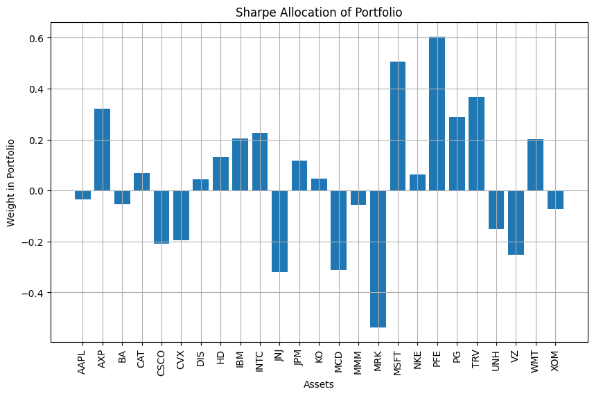

```python
plt.figure(figsize=(10, 6))
plt.bar(gross_return_100.columns, w_MSR)
plt.title('Sharpe Allocation of Portfolio')
plt.xlabel('Assets')
plt.ylabel('Weight in Portfolio')
plt.xticks(rotation=90)
plt.grid(True)
plt.show()
```

## e) Plot the efficient frontier allocations as an area plot for the case when short selling is not allowed, with the allocation volatility on the x-axis.

**Method:**

- Define a range of target returns covering the efficient frontier without short selling.
- For each target return, compute the corresponding minimum-variance portfolio and record both its weights and volatility.
- Collect all portfolio weights into a matrix aligned with their volatilities.
- Create an area plot with volatility on the x-axis and the asset allocation proportions stacked vertically.

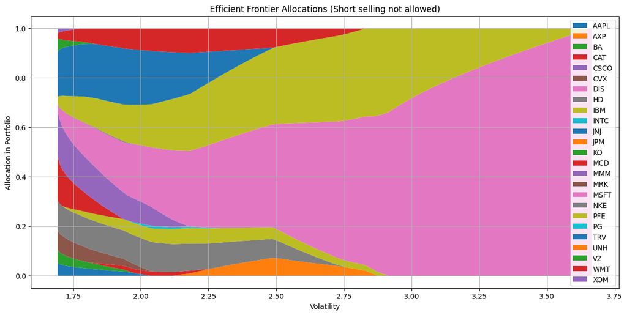

```python
target_returns_ef = np.linspace(portfolio_ret[np.argmin(volatility_no_short)]/100, max(mu_100/100), 100)
weights_1d = np.zeros((100, 25)); volatility_1d =np.zeros(100)
for i in range(len(target_returns_ef)):
    weights_1d[i, :],  volatility_1d[i],_ = MVS(mu_100/100, covMat, target_returns_ef[i], allow_short=False)
plt.figure(figsize=(15, 7))
plt.stackplot(volatility_1d, weights_1d.T, labels=gross_return_100.columns)
plt.title('Efficient Frontier Allocations (Short selling not allowed)')
plt.xlabel('Volatility')
plt.ylabel('Allocation in Portfolio')
plt.legend()
plt.grid(True)
plt.show()
```

# Discussion

*Looking at the mean-volatility diagram, did Apple look like a good investment? Which stocks are in the no-short minimum variance portfolio?*

Based on the mean-volatility diagram, we can see that Apple does not seem to be a good investment during the sample period. Its position on the diagram shows the highest volatility of all stocks at ≈7.80 while also having the lowest average return ≈99.41. So simply put, Apple shows the worst possible risk-return trade-off among all of the assets we have plotted.

The stocks (allocation) in the No-short MVP composition:

- AAPL: 0.0532
- BA: 0.0549
- CVX: 0.0792
- HD: 0.1207
- MCD: 0.1915
- MMM: 0.1881
- MSFT: 0.0092
- NKE: 0.0025
- PFE: 0.0237
- TRV: 0.1800
- VZ: 0.0566
- WMT: 0.0192
- XOM: 0.0211

# 2. Backtesting the standard Markowitz model

Backtest the Markowitz model using the backtesting procedure outlined above for the following portfolios (by target portfolio we mean a portfolio with weekly gross return target, u0 = 1,0025):

- the target portfolio, with shorting allowed,
- the target portfolio, shorting not allowed
- the minimum variance portfolio (shorting allowed)
- The Sharpe portfolio1, shorting not allowed
- the equal weight portfolio (rebalanced every week),

```python
def MVP(Sigma_mat, allow_short=False):

    Sigma = np.array(Sigma_mat)
    n = Sigma.shape[0]
    w = cvx.Variable(n)

    # objective: minimize w^T Σ w
    objective = cvx.quad_form(w, Sigma)

    constraints = [cvx.sum(w) == 1]
    if not allow_short:
        constraints.append(w >= 0)

    prob = cvx.Problem(cvx.Minimize(objective), constraints)
    prob.solve(solver=cvx.SCS)

    weights = w.value
    weights = np.array(weights).flatten()
    weights = weights / weights.sum()

    vol = float(np.sqrt(weights.T @ Sigma @ weights))

    return weights


def target_weights_no_short(mean_returns, cov_mat, mu0):

    num_stocks = len(mean_returns)

    if np.min(mean_returns) > mu0:
        idx = np.argmin(mean_returns)
        w = np.zeros(num_stocks)
        w[idx] = 1.0
        return w

    if np.max(mean_returns) < mu0:
        idx = np.argmax(mean_returns)
        w = np.zeros(num_stocks)
        w[idx] = 1.0
        return w

    w, _, _ = MVS(mean_returns, cov_mat, mu0, allow_short=False)

    return w


def sharpe_weights_no_short(mu, Q, rf=0.0):

    mu_hat = mu - rf

    # Objective: minimize y^T Q y
    def objective(y):
        return y @ Q @ y

    constraints = ({'type': 'eq','fun': lambda y: mu_hat @ y - 1})
    bounds = [(0, None) for _ in range(len(mu))]

    y0 = np.maximum(mu_hat, 1e-6)
    y0 = y0 / (mu_hat @ y0)

    res = minimize(objective, y0, constraints=constraints, bounds=bounds)

    y = res.x
    x = y / np.sum(y)

    return x
```

```python
wMVP_noShort = MVP(covMat, allow_short=False)
print("No-short MVP composition:")
for stock, weight in zip(gross_return_100.columns, wMVP_noShort):
    if weight > 1e-4:
        print(f"{stock}: {weight:.4f}")
```

```
No-short MVP composition:
AAPL: 0.0532
BA: 0.0549
CVX: 0.0792
HD: 0.1207
MCD: 0.1915
MMM: 0.1881
MSFT: 0.0092
NKE: 0.0025
PFE: 0.0237
TRV: 0.1800
VZ: 0.0566
WMT: 0.0192
XOM: 0.0211
```

## a) Plot the evolution of the portfolios' in the same plot

**Method:**

- Set the target weekly gross return and initialize portfolio values for all five strategies.
- For each week in the backtest, use the previous 100 weekly returns to estimate mean returns and the covariance matrix.
- Compute portfolio weights for each strategy.
- Apply these weights to the next week’s realized returns to update the portfolio values.
- Repeat the estimation and rebalancing each week until the end of the sample.

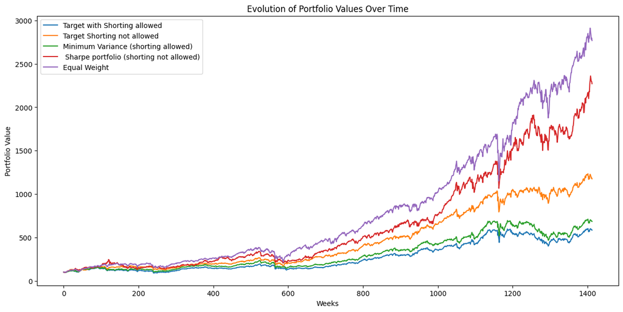

```python
mu0 = 1.0025
numberOfWeeks = len(gross_return) - 100
initial = 100
portfolioValueShort = [initial]
portfolioValueNoShort = [initial]
portfolioValuesMinVar = [initial]
portfolioValueEW = [initial]
portfolioValueSharpeNoShort = [initial]

weightslist = []
weightsTargetShort_history = []
weightsMinVar_history = []
weightsSharpeNoShort_history = []
for week in range(numberOfWeeks):
    currentWindow = gross_return[week:week + 100].iloc[:, :-1]
    meanReturns = 100 + currentWindow.mean() * 100
    covMat = currentWindow.cov()
    numStocks = len(meanReturns)
    WeeklyReturnsCur = gross_return.iloc[:, :-1].iloc[week + 100]
    mu_vec = meanReturns / 100.0
    mu_vec_sharpe = currentWindow.mean().values

    weightsNoShort = target_weights_no_short(mu_vec, covMat, mu0)

    wMinVariance = MVP(covMat, allow_short=True)
    equalWeightPortfolio = np.full(len(meanReturns), 1/len(meanReturns))
    weightsTargetShort,volShort,_ = MVS(meanReturns / 100, covMat, mu0, allow_short=True)
    wSharpeNoShort = sharpe_weights_no_short(mu_vec_sharpe, covMat, rf = 0.0)

    weightsTargetShort_history.append(weightsTargetShort)
    weightsMinVar_history.append(wMinVariance)
    weightsSharpeNoShort_history.append(wSharpeNoShort)

    weightslist.append(weightsNoShort)
    portfolioValueNoShort.append(portfolioValueNoShort[-1] * (1 + np.dot(WeeklyReturnsCur, weightsNoShort)))
    portfolioValueShort.append(portfolioValueShort[-1] * (1 + np.dot(WeeklyReturnsCur, weightsTargetShort)))
    portfolioValueEW.append(portfolioValueEW[-1] * (1 + np.dot(WeeklyReturnsCur, equalWeightPortfolio)))
    portfolioValuesMinVar.append(portfolioValuesMinVar[-1] * (1 + np.dot(WeeklyReturnsCur, wMinVariance)))
    portfolioValueSharpeNoShort.append(portfolioValueSharpeNoShort[-1] * (1 + np.dot(WeeklyReturnsCur, wSharpeNoShort)))

weeks = list(range(numberOfWeeks +1))

plt.figure(figsize=(15, 7))
plt.plot(weeks, portfolioValueShort, label='Target with Shorting allowed')
plt.plot(weeks, portfolioValueNoShort, label='Target Shorting not allowed')
plt.plot(weeks, portfolioValuesMinVar, label='Minimum Variance (shorting allowed)')
plt.plot(weeks, portfolioValueSharpeNoShort, label=' Sharpe portfolio (shorting not allowed)')
plt.plot(weeks, portfolioValueEW, label='Equal Weight')
plt.title('Evolution of Portfolio Values Over Time')
plt.xlabel('Weeks')
plt.ylabel('Portfolio Value')
plt.legend()
plt.show()
```

## b) Include a table with the portfolio values at every 100th week, beginning at week 0.

**Method:**

- Select every 100th week from the backtesting period, starting at week 0.
- Extract the corresponding portfolio values for each strategy at these week indices.
- Collect the week numbers and portfolio values into a structured table.

```python
weekIndices = list(range(0, numberOfWeeks + 1, 100))
portfolioValues100 = {
    "Week": weekIndices,
    "Target with Short Selling": [portfolioValueShort[i] for i in weekIndices],
    "Target without Short Selling": [portfolioValueNoShort[i] for i in weekIndices],
    "Equal Weight": [portfolioValueEW[i] for i in weekIndices],
    "Minimum Variance": [portfolioValuesMinVar[i] for i in weekIndices],
    "Sharpe without Short Selling": [portfolioValueSharpeNoShort[i] for i in weekIndices]}
portfolioValuesDf = pd.DataFrame(portfolioValues100)
portfolioValuesDf
```

|  | Week | Target with Short Selling | Target without Short Selling | Equal Weight | Minimum Variance | Sharpe without Short Selling |
| --- | --- | --- | --- | --- | --- | --- |
| 0 | 0 | 100.000000 | 100.000000 | 100.000000 | 100.000000 | 100.000000 |
| 1 | 100 | 139.599963 | 154.929221 | 175.928928 | 145.449239 | 170.440726 |
| 2 | 200 | 116.505682 | 156.686959 | 179.181153 | 132.721119 | 145.965485 |
| 3 | 300 | 116.766487 | 150.673673 | 200.156805 | 134.190425 | 160.879169 |
| 4 | 400 | 143.787349 | 195.101446 | 261.433644 | 168.826744 | 224.691466 |
| 5 | 500 | 168.887496 | 239.786923 | 369.303581 | 201.444057 | 309.917782 |
| 6 | 600 | 133.749062 | 210.685506 | 304.297868 | 154.519898 | 238.467833 |
| 7 | 700 | 161.997409 | 289.323534 | 479.927574 | 195.072762 | 350.327028 |
| 8 | 800 | 238.507547 | 404.415668 | 644.017164 | 285.871943 | 510.811563 |
| 9 | 900 | 291.955387 | 502.501840 | 857.266234 | 349.468053 | 650.059250 |
| 10 | 1000 | 355.988883 | 652.650064 | 1020.566724 | 422.610577 | 760.954582 |
| 11 | 1100 | 425.375634 | 819.553265 | 1350.971595 | 494.254250 | 1090.382139 |
| 12 | 1200 | 537.223587 | 1053.484570 | 1825.202986 | 629.907322 | 1527.987507 |
| 13 | 1300 | 447.606736 | 998.440321 | 2119.599621 | 509.046797 | 1763.671780 |
| 14 | 1400 | 595.748532 | 1223.392966 | 2818.911299 | 703.278668 | 2157.202173 |

## c) Calculate annualized means, volatilities, Sharpe ratios, alpha (w.r.t. S&P500), maximum drawdown and average ENCs for the portfolios’ weekly percentage returns over the backtesting period.

**Method:**

- Compute weekly percentage returns from each portfolio’s value series over the full backtesting period.
- Convert the weekly returns into annualized means and volatilities.
- Calculate Sharpe ratios and average ENCs based on the weekly returns and portfolio weights.
- Determine maximum drawdowns by comparing each portfolio’s value to its running peak.
- Run a regression of portfolio returns on S&P 500 returns to obtain annualized alpha and beta.

```python
def portfolioMetrics(portfolioValues, portfolioWeights):
    weeklyReturns = np.diff(portfolioValues) / portfolioValues[:-1]
    annualizedMean = np.mean(weeklyReturns) * 52
    annualizedVolatility = np.std(weeklyReturns) * np.sqrt(52)
    averageEnc = 1 / np.sum(portfolioWeights ** 2)
    sharpeRatio = annualizedMean/annualizedVolatility
    return annualizedMean, annualizedVolatility, averageEnc, sharpeRatio

def maxDrawdown(portfolioValues):
    drawdown = (pd.Series(portfolioValues).cummax() - pd.Series(portfolioValues)) / pd.Series(portfolioValues).cummax()
    return drawdown.max()

def compute_alpha(portfolio_returns, sp500_returns):
    X = sm.add_constant(sp500_returns)
    model = sm.OLS(portfolio_returns, X).fit()

    weekly_alpha = model.params[0]

    return weekly_alpha

def get_weekly_returns(portfolioValues):
    return np.diff(portfolioValues) / portfolioValues[:-1]
```

```python
def compute_enc_over_time(weights_history, allow_short=False, eps=1e-12):

    W = np.asarray(weights_history)  # (T, N)

    if allow_short:
        gross = np.sum(W, axis=1, keepdims=True)
        Wn = W / np.maximum(gross, eps)
    else:
        s = np.sum(W, axis=1, keepdims=True)
        Wn = W / np.maximum(s, eps)

    enc_t = 1.0 / np.sum(Wn**2, axis=1)
    return float(np.mean(enc_t)), enc_t


def portfolioMetrics1(portfolioValues, weights_history, allow_short=False):
    weeklyReturns = np.diff(portfolioValues) / portfolioValues[:-1]
    annualizedMean = np.mean(weeklyReturns) * 52
    annualizedVolatility = np.std(weeklyReturns) * np.sqrt(52)

    averageEnc, enc_series = compute_enc_over_time(weights_history, allow_short=allow_short)

    sharpeRatio = annualizedMean / annualizedVolatility
    return annualizedMean, annualizedVolatility, averageEnc, sharpeRatio, enc_series
```

```python
weightsEW_history = np.tile(equalWeightPortfolio, (numberOfWeeks, 1))

meanShort, volatilityShort, encsShort, sharpeRatioShort, _ = portfolioMetrics1(portfolioValueShort, weightsTargetShort_history, allow_short=True)
meanMinVar, volatilityMinVar, encsMinVar, sharpeMinVar, _ = portfolioMetrics1(portfolioValuesMinVar, weightsMinVar_history, allow_short=True)
meanEqualWeight, volatilityEqualWeight, encsEqualWeight, sharpeEqualWeight, _ = portfolioMetrics1(portfolioValueEW, weightsEW_history, allow_short=False)
meanNoShort, volatilityNoShort, encsNoShort, sharpeRatioNoShort, _ = portfolioMetrics1(portfolioValueNoShort, weightslist, allow_short=False)
meanSharpeNS, volatilitySharpeNS, encsSharpeNS, sharpeSharpeNS, _ = portfolioMetrics1(portfolioValueSharpeNoShort, weightsSharpeNoShort_history, allow_short=False)

# Max drawdowns
mdShort = maxDrawdown(portfolioValueShort)
mdMinVar = maxDrawdown(portfolioValuesMinVar)
mdEW = maxDrawdown(portfolioValueEW)
mdNoShort = maxDrawdown(portfolioValueNoShort)
mdSharpeNS = maxDrawdown(portfolioValueSharpeNoShort)

# Weekly returns for alpha
weeklyShort = get_weekly_returns(portfolioValueShort)
weeklyMinVar = get_weekly_returns(portfolioValuesMinVar)
weeklyEW = get_weekly_returns(portfolioValueEW)
weeklyNoShort = get_weekly_returns(portfolioValueNoShort)
weeklySharpeNS = get_weekly_returns(portfolioValueSharpeNoShort)

# Alphas (annual, vs S&P500)
alphaShort = compute_alpha(weeklyShort, sp500_returns)
alphaMinVar = compute_alpha(weeklyMinVar, sp500_returns)
alphaEW = compute_alpha(weeklyEW, sp500_returns)
alphaNoShort = compute_alpha(weeklyNoShort, sp500_returns)
alphaSharpeNS = compute_alpha(weeklySharpeNS, sp500_returns)
```

```python
portfolioDf = pd.DataFrame({
    'Portfolio Type': ['Target (short allowed)','Minimum Variance','Equal Weight','Target (no short)','Sharpe (no short)'],
    'Annualized Mean': [meanShort, meanMinVar, meanEqualWeight, meanNoShort, meanSharpeNS],
    'Annualized Volatility': [volatilityShort, volatilityMinVar, volatilityEqualWeight, volatilityNoShort, volatilitySharpeNS],
    'Average ENCs': [encsShort, encsMinVar, encsEqualWeight, encsNoShort, encsSharpeNS],
    'Sharpe Ratio': [sharpeRatioShort, sharpeMinVar, sharpeEqualWeight, sharpeRatioNoShort, sharpeSharpeNS],
    'Max Drawdown': [mdShort, mdMinVar, mdEW, mdNoShort, mdSharpeNS],
    'Alpha (w.r.t S&P500)': [alphaShort, alphaMinVar, alphaEW, alphaNoShort, alphaSharpeNS]}) #weekly
```

```python
portfolioDf.round(5)
```

|  | Portfolio Type | Annualized Mean | Annualized Volatility | Average ENCs | Sharpe Ratio | Max Drawdown | Alpha (w.r.t S&P500) |
| --- | --- | --- | --- | --- | --- | --- | --- |
| 0 | Target (short allowed) | 0.07724 | 0.15553 | 3.08357 | 0.49664 | 0.43199 | 0.00070 |
| 1 | Minimum Variance | 0.08332 | 0.15704 | 3.13005 | 0.53057 | 0.39144 | 0.00083 |
| 2 | Equal Weight | 0.13714 | 0.17092 | 25.00000 | 0.80240 | 0.43773 | 0.00118 |
| 3 | Target (no short) | 0.10177 | 0.14722 | 5.90860 | 0.69124 | 0.35175 | 0.00096 |
| 4 | Sharpe (no short) | 0.13253 | 0.18596 | 4.13178 | 0.71266 | 0.47740 | 0.00131 |

## d) Plot the portfolio percentage weights for the no short target portfolio using the area plot.

**Method:**

- Collect the weekly portfolio weights from the target portfolio without short selling during the backtest.
- Create an area plot showing how the allocation across assets evolves week by week.

[figure not shown]

```python
tickers = gross_return.columns[:-1]
AreaPlotdf = pd.DataFrame(weightslist, columns=tickers)
longWeights = AreaPlotdf.clip(lower=0)
ax = longWeights.plot.area(figsize=(12, 8))
plt.title("Area plot of weights for the no-short target portfolio")
plt.xlabel("Weeks")
plt.ylabel("Weights")
plt.legend(loc='upper left', bbox_to_anchor=(1.02, 1), ncol=1)
plt.tight_layout()
plt.show()
```

# Discussion:

*How do these portfolios compare? What does c) and d) tell you?*

The backtesting results from this question show a performance difference between the five portfolio strategies. The Equal Weight porfolio achieved the highest final portfolio value at 2818 at week 1400 and also the highest annualized mean return at around 13.7%, which therefore outperformed the other portfolios.

The Sharpe portfolio with no shorting allowed was the second best performer with annualized returns of around 13.25%. This reflects optimizing return relative to risk without leverage delivered strong gains. However, it has a high volatility and maximum drawdown which might indicate that the improved return came at the cost of greater downside risk.

The Target return portfolio without short selling performed noticeably better than its short selling version. The short-allowed version produced the worst Sharpe ratio and Alpha which indicates that the unconstrained weights caused unstable allocations and therefore potentially large negative exposures that reduced its performance.

Finally, in d) we can see the no-short target portfolio's weights change significantly over time. This can be explained since it is highly sensitive to the most recent return estimates, which results in a high frequency in the reallocation.

# 3. Benchmark allocation

Determine the ”mean-tracking error” efficient frontier using S&P 500 as the benchmark index, when V(0) = L(0) = 100. Assume that a risk-free asset is available with R0 = 1 and use the last 100 weekly returns in the data for parameter estimation.

## a) Plot the optimal hedge portfolio allocation as a bar plot and include the values in a table.

**Method:**

- Use the last 100 weekly returns to estimate the covariance matrix of the individual stocks and their covariances with the S&P 500.
- Compute the optimal hedge portfolio weights by inverting the stock covariance matrix and multiplying by the covariance with the benchmark.

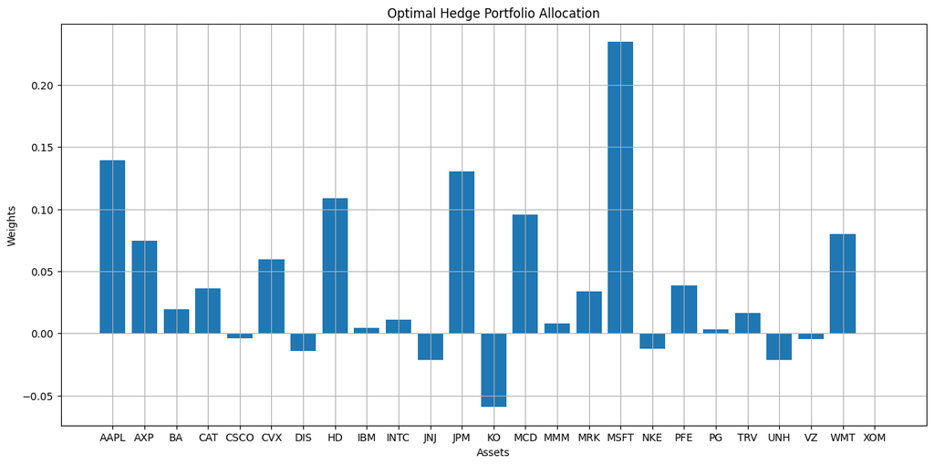

```python
stockSCM = gross_return.iloc[-100:, :-1].cov()
covStocksSnP = gross_return.iloc[-100:, :-1].apply(lambda x: x.cov(gross_return.iloc[-100:, -1]))
inverseStockSCM = np.linalg.inv(stockSCM.values)
wh = inverseStockSCM.dot(covStocksSnP.values)

plt.figure(figsize = (15,7))
plt.bar(gross_return_100.columns, wh)
plt.title('Optimal Hedge Portfolio Allocation')
plt.xlabel('Assets')
plt.ylabel('Weights')
plt.grid(True)
plt.show()

whdf = pd.DataFrame({"Stocks": tickers, "Hedge weight": wh})
```

```python
whdf
```

|  | Stocks | Hedge weight |
| --- | --- | --- |
| 0 | AAPL | 0.139113 |
| 1 | AXP | 0.074283 |
| 2 | BA | 0.019144 |
| 3 | CAT | 0.035918 |
| 4 | CSCO | -0.004192 |
| 5 | CVX | 0.059593 |
| 6 | DIS | -0.014478 |
| 7 | HD | 0.108961 |
| 8 | IBM | 0.004169 |
| 9 | INTC | 0.010814 |
| 10 | JNJ | -0.021323 |
| 11 | JPM | 0.130371 |
| 12 | KO | -0.059289 |
| 13 | MCD | 0.095326 |
| 14 | MMM | 0.007715 |
| 15 | MRK | 0.033972 |
| 16 | MSFT | 0.234445 |
| 17 | NKE | -0.012493 |
| 18 | PFE | 0.038335 |
| 19 | PG | 0.003306 |
| 20 | TRV | 0.016405 |
| 21 | UNH | -0.021132 |
| 22 | VZ | -0.004794 |
| 23 | WMT | 0.079727 |
| 24 | XOM | 0.000133 |

## b) Plot the “mean – tracking error” efficient frontier

**Method:**

- Use the last 100 weekly returns to estimate the mean returns and covariance matrix of the stocks, as well as the variance of the S&P 500.
- Define a range of target portfolio returns for the mean–tracking error analysis.
- For each target return, compute the portfolio weights that minimize the tracking error relative to the benchmark.
- Calculate the expected excess return over the benchmark and the corresponding tracking error.

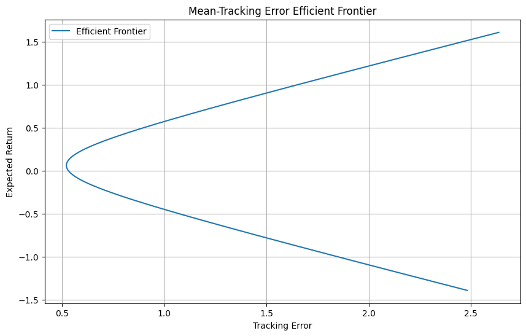

```python
R0 = 1; L0 = V0 = 100

stockReturnsLast100 = gross_return.iloc[-100:, :-1]
meanReturns = stockReturnsLast100.mean() +1
meanReturnSnP = gross_return.iloc[-100:, -1].mean() +1
covMat = stockReturnsLast100.cov()
Var_RL = gross_return.iloc[-100:, -1].var()
Var_L1 = L0**2 * Var_RL

mu = np.arange(0.99, 1.02, 0.0001)
onesVector = np.ones(len(stockReturnsLast100.columns))
trackingErrors = []; expectedExcessReturns = []

def calculate(mu_0):
    numerator = ((mu_0 - R0) * V0 - wh.T*V0 @ (meanReturns - R0 * onesVector))
    denominator = (meanReturns - R0 * onesVector).T @ inverseStockSCM @ (meanReturns - R0 * onesVector)
    w = (numerator / denominator) * (inverseStockSCM @ (meanReturns - R0 * onesVector)) + wh* V0
    w0 = V0 - w.T @ onesVector
    expectedExcess = w0 * R0 + w @ meanReturns - meanReturnSnP * V0
    trackingError = np.sqrt(w.T @ covMat @ w - 2 * w.T @ covStocksSnP*V0 + Var_L1) #FL24 slide 2 & 5
    return expectedExcess, trackingError

for mu_0 in mu:
    expectedExcess, trackingError = calculate(mu_0)
    expectedExcessReturns.append(expectedExcess)
    trackingErrors.append(trackingError)

plt.figure(figsize=(10, 6))
plt.plot(trackingErrors, expectedExcessReturns, '-', label='Efficient Frontier')
plt.title('Mean-Tracking Error Efficient Frontier')
plt.xlabel('Tracking Error')
plt.ylabel('Expected Return')
plt.legend()
plt.grid(True)
plt.show()
```

## c) What is the smallest tracking error that can be achieved?

**Method:**

- Identify the minimum value in the computed tracking errors from the mean–tracking error efficient frontier.

```python
smallestTrackingError = min(trackingErrors)
print(f"The smallest tracking error: {smallestTrackingError}")
```

```
The smallest tracking error: 0.5212157763537533
```

## d) What is the expected excess return (in excess of S&P500) of the minimum tracking error portfolio?

**Method:**

- Locate the portfolio corresponding to the minimum tracking error on the efficient frontier.
- Extract the expected excess return of this portfolio relative to the S&P 500.

```python
ExcessReturn = expectedExcessReturns[np.argmin(trackingErrors)]
print(f"Expected excess return: {(ExcessReturn)}")
```

```
Expected excess return: 0.06136550304466937
```

# 4. Backtesting equal risk contribution portfolios

Repeat the backtest for

- the MVP, shorting not allowed
- the risk parity portfolio

## a) Plot the evolution of these portfolios

**Method:**

- Initialize portfolio values for the MVP (no short selling) and risk parity portfolios.
- For each week in the backtest, use the previous 100 weekly returns to estimate the covariance matrix.
- Compute the portfolio weights for each strategy
- Apply these weights to the next week’s realized returns to update portfolio values.
- Repeat this process weekly throughout the backtesting period.

```python
def risk_parity_weights(covMat):

    Sigma = np.asarray(covMat)
    n = Sigma.shape[0]

    # Objektive: sum_i (RC_i - 1/n)^2,
    # where RC_i = w_i (Σ w)_i / (w^T Σ w)
    def objective(w):

        if np.any(w < 0):
            return 1e6

        Sigma_w = Sigma @ w
        port_var = w @ Sigma_w

        if port_var <= 0:
            return 1e6

        RC = w * Sigma_w / port_var

        return np.sum((RC - 1.0 / n) ** 2)

    #initail guess
    vol = np.sqrt(np.diag(Sigma))
    w0 = 1.0 / vol
    w0 = w0 / w0.sum()

    bounds = [(0.0, None)] * n  # no shorting

    res = minimize(objective, w0, method='SLSQP', bounds=bounds)

    if not res.success:
        w = w0
    else:
        w = res.x

    w = w / w.sum()

    return w
```

```python
numberOfWeeks = len(gross_return) - 100
initial = 100

portfolioValueMVP_noShort = [initial]
portfolioValueRiskParity = [initial]

weightsMVP_noShort_history = []
weightsRiskParity_history = []

for week in range(numberOfWeeks):
    currentWindow = gross_return.iloc[week:week + 100, :-1]
    covMat = currentWindow.cov()

    wMVP_noShort = MVP(covMat, allow_short=False)
    weightsMVP_noShort_history.append(wMVP_noShort)

    wRP = risk_parity_weights(covMat)
    weightsRiskParity_history.append(wRP)

    WeeklyReturnsCur = gross_return.iloc[week + 100, :-1].values

    portfolioValueMVP_noShort.append(
        portfolioValueMVP_noShort[-1] * (1 + WeeklyReturnsCur @ wMVP_noShort))

    portfolioValueRiskParity.append(
        portfolioValueRiskParity[-1] * (1 + WeeklyReturnsCur @ wRP))

weeks4 = list(range(numberOfWeeks + 1))
```

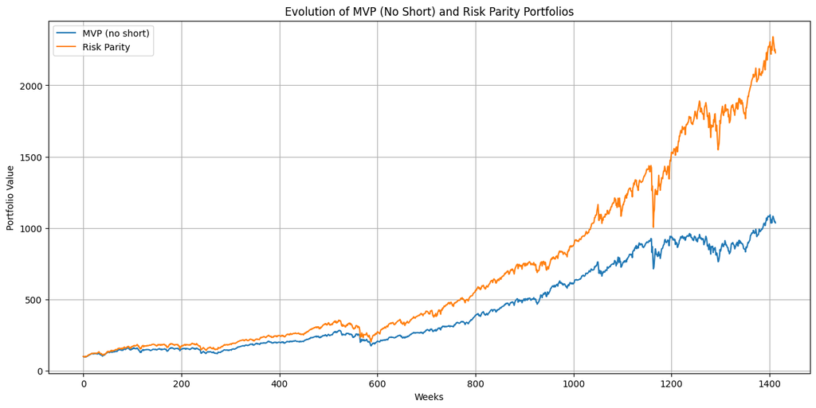

```python
plt.figure(figsize=(15, 7))
plt.plot(weeks4, portfolioValueMVP_noShort, label='MVP (no short)')
plt.plot(weeks4, portfolioValueRiskParity, label='Risk Parity')
plt.title('Evolution of MVP (No Short) and Risk Parity Portfolios')
plt.xlabel('Weeks')
plt.ylabel('Portfolio Value')
plt.legend()
plt.grid(True)
plt.show()
```

## b) Include a table with the portfolio values at every 100th week, beginning at week 0

**Method:**

- Select every 100th week from the backtesting period, starting at week 0.
- Extract the corresponding portfolio values for the MVP (no short) and risk parity portfolios at these weeks.

```python
weekIndices4 = list(range(0, numberOfWeeks + 1, 100))

portfolioValues4_100 = {"Week": weekIndices4,
    "MVP (no short)": [portfolioValueMVP_noShort[i] for i in weekIndices4],
    "Risk Parity":    [portfolioValueRiskParity[i]   for i in weekIndices4],}

portfolioValues4Df = pd.DataFrame(portfolioValues4_100)
portfolioValues4Df
```

|  | Week | MVP (no short) | Risk Parity |
| --- | --- | --- | --- |
| 0 | 0 | 100.000000 | 100.000000 |
| 1 | 100 | 151.576371 | 168.852096 |
| 2 | 200 | 151.783608 | 173.460619 |
| 3 | 300 | 146.653493 | 186.710992 |
| 4 | 400 | 199.934355 | 246.075873 |
| 5 | 500 | 255.153875 | 336.593401 |
| 6 | 600 | 207.893229 | 273.059040 |
| 7 | 700 | 283.150440 | 414.729950 |
| 8 | 800 | 389.592253 | 564.508507 |
| 9 | 900 | 494.179705 | 740.201685 |
| 10 | 1000 | 612.669519 | 876.634360 |
| 11 | 1100 | 749.475347 | 1143.510486 |
| 12 | 1200 | 941.737218 | 1531.159825 |
| 13 | 1300 | 837.949463 | 1733.662418 |
| 14 | 1400 | 1083.381652 | 2281.037842 |

## c) Calculate annualized means and volatilities, Sharpe ratios, alpha (w.r.t. S&P500), maximum drawdown and average ENCs for the portfolios’ weekly percentage returns over the backtesting period.

**Method:**

- Compute weekly percentage returns from the MVP (no short) and risk parity portfolio values.
- Annualize the weekly returns to obtain mean returns and volatilities.
- Calculate Sharpe ratios and average ENCs based on the latest portfolio weights.
- Determine maximum drawdowns by comparing portfolio values to their running peaks.
- Regress portfolio returns on S&P 500 returns to calculate annualized alpha and beta.

```python
meanMVP_ns, volMVP_ns, encsMVP_ns, sharpeMVP_ns, _ = portfolioMetrics1(
    portfolioValueMVP_noShort,
    weightsMVP_noShort_history,
    allow_short=False)

meanRP, volRP, encsRP, sharpeRP, _ = portfolioMetrics1(
    portfolioValueRiskParity,
    weightsRiskParity_history,
    allow_short=False)

mdMVP_ns = maxDrawdown(portfolioValueMVP_noShort)
mdRP = maxDrawdown(portfolioValueRiskParity)

weeklyMVP_ns = get_weekly_returns(portfolioValueMVP_noShort)
weeklyRP = get_weekly_returns(portfolioValueRiskParity)

sp500_returns = gross_return.iloc[100:, -1].values

alphaMVP_ns = compute_alpha(weeklyMVP_ns, sp500_returns)
alphaRP = compute_alpha(weeklyRP, sp500_returns)

portfolioDf4 = pd.DataFrame({
    'Portfolio Type': ['MVP (no short)', 'Risk Parity'],
    'Annualized Mean': [meanMVP_ns, meanRP],
    'Annualized Volatility': [volMVP_ns, volRP],
    'Average ENCs': [encsMVP_ns, encsRP],
    'Sharpe Ratio': [sharpeMVP_ns, sharpeRP],
    'Max Drawdown': [mdMVP_ns, mdRP],
    'Alpha (w.r.t S&P500)': [alphaMVP_ns, alphaRP]}) #weekly

portfolioDf4
```

|  | Portfolio Type | Annualized Mean | Annualized Volatility | Average ENCs | Sharpe Ratio | Max Drawdown | Alpha (w.r.t S&P500) |
| --- | --- | --- | --- | --- | --- | --- | --- |
| 0 | MVP (no short) | 0.096631 | 0.143630 | 6.230224 | 0.672778 | 0.383777 | 0.000856 |
| 1 | Risk Parity | 0.127289 | 0.159635 | 22.883421 | 0.797374 | 0.428147 | 0.001105 |

## d) Plot the weights of the MVP and the risk parity portfolio over the backtest period using an area plot (two separate plots)

**Method:**

- Convert the weekly portfolio weight histories for MVP (no short) and risk parity portfolios into separate DataFrames.
- Create an area plot for the MVP (no short) portfolio showing the evolution of asset weights over time.
- Create a separate area plot for the risk parity portfolio in the same manner.

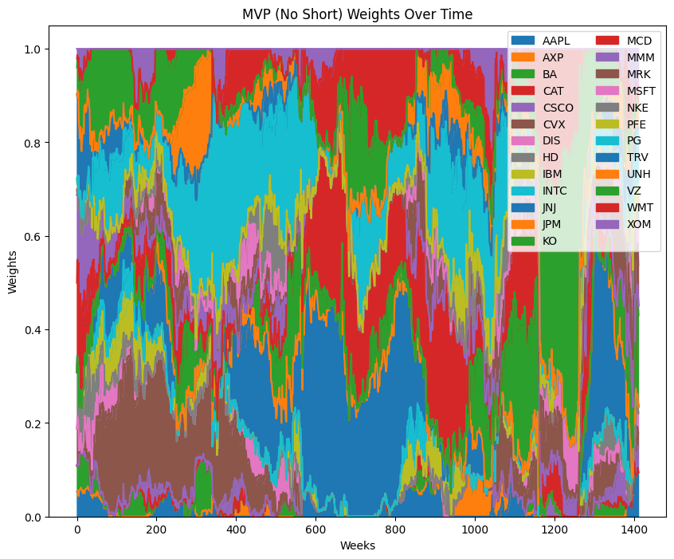

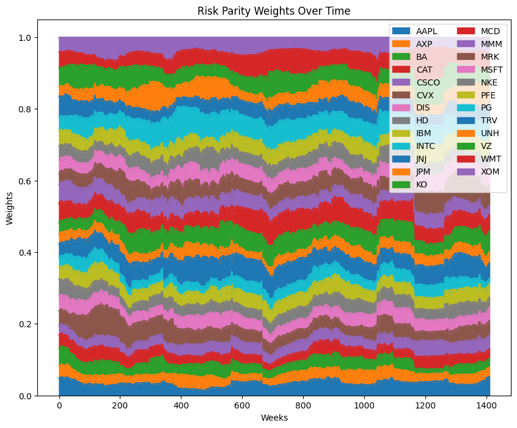

```python
weightsMVP_ns_df = pd.DataFrame(weightsMVP_noShort_history, columns=gross_return.columns[:-1])
weightsRP_df = pd.DataFrame(weightsRiskParity_history, columns=gross_return.columns[:-1])

plt.figure(figsize=(10, 8))
weightsMVP_ns_df.clip(lower=0).plot.area(ax=plt.gca())
plt.title("MVP (No Short) Weights Over Time")
plt.xlabel("Weeks")
plt.ylabel("Weights")
plt.legend(loc='upper right', ncol=2)
plt.show()

plt.figure(figsize=(10, 8))
weightsRP_df.clip(lower=0).plot.area(ax=plt.gca())
plt.title("Risk Parity Weights Over Time")
plt.xlabel("Weeks")
plt.ylabel("Weights")
plt.legend(loc='upper right', ncol=2)
plt.show()
```

# Discussion

*How do these portfolios compare?*

The backtest for the Risk Parity portfolio and the no-shorting allowed MVP shows that the Risk Parity portfolio outperforms in terms of growth. The final value of Risk Parity is about 2281, while the no-short MVp has about 1083. The annualized mean return is also higher for the Risk Parity at 12.7% in comparison to the MVP at 9.7%. This higher return comes with a (surpisingly) low increase in volatility (15.96% vs 14.36%). Risk parity also shows a higher alpha relative to the S&P500 at 0.057, whereas the MVP had a value at 0.045. This indicates a stronger risk-ajusted performance of the benchmark.

On the risk side, the Risk Parity has a larger maximum drawdown (0.43 vs 0.38). However this is not that extreme given the much higher long-term returns.

All in all, this balanced risk allocation seemst to deliver a better trade-off between return and risk.